# CIENCIA DE DATOS GEOGRÁFICA - CLASE 5

Angie Scetta

FLACSO, Julio 2022

# GEOLOCALIZACIÓN, RECORRIDOS Y DISTANCIAS EN LA CIUDAD

Hemos llegado al final del módulo, y como cierre nos enfocaremos en 2 herramientas muy útiles a la hora de trabajar con datos geográficos:

1. Geolocalización de información a partir de una dirección. El paquete *tmaptools*.
2. Cáclulo de ruteos (distancia y duración) entre 2 o más puntos de interés. El paquete *osrm*.

Cabe destacar que, para utilizar ambas herramientas en un dataset con más de un registro, vamos a aprender crear nuestras propias *funciones*.

Comencemos activando (e instalando en caso de ser necesario) todas las librerías que utilizaremos hoy:

```r
#install.packages("tidyverse")
library(tidyverse)
#install.packages("sf")
library(sf)
#install.packages("leaflet")
library(leaflet)
#install.packages("tmaptools")
library(tmaptools)
#install.packages("osrm")
library(osrm)
```

## GEOLOCALIZACIÓN DE INFORMACIÓN

La **geolocalización o georreferenciación** es el proceso de determinar la posición geográfica exacta (conjunto de coordenadas) de un objeto o evento en el territorio. Esto resulta de gran interés para quienes se analizan datos urbanos ya que muchas veces puede ocurrir que tengamos una base de datos con direcciones (calle y altura) asignadas a cada registro, pero sin coordenadas que nos permitan saber la ubicación exacta en el territorio.

Desde RStudio por suerte tenemos varios paquetes que nos permiten geolocalizar direcciones, pero aprovechando que ya conocemos [OpenStreetMap](https://www.openstreetmap.org/) y todos los beneficios que conlleva utilizar este mapa colaborativo, hoy vamos a trabajar con el paquete *tmaptools* que geolocaliza los registros a partir de la base de datos de OpenStreetMap. Toda la documentación necesaria la pueden encontrar en este [link](https://cran.r-project.org/web/packages/tmaptools/tmaptools.pdf).

### GEOLOCALIZACIÓN SIMPLE

Veamos un ejemplo utilizando la función `geocode_OSM()` y georreferenciemos la Sede de la Facultad Latinoamericana de Ciencias Sociales (FLACSO) que queda en Tucumán 1966 en CABA, Buenos Aires, Argentina:

```r
FLACSO_arg <- geocode_OSM("Tucumán 1966, CABA, Buenos Aires, Argentina")
```

```r
FLACSO_arg
```

```
## $query
## [1] "Tucumán 1966, CABA, Buenos Aires, Argentina"
##
## $coords
##         x         y
## -58.39498 -34.60221
##
## $bbox
##      xmin      ymin      xmax      ymax
## -58.39503 -34.60226 -58.39493 -34.60216
```

En el resultado se puede ver que la línea de código realizada nos devuelve una lista compuesta por 3 datos respecto a la ubicación geográfica de la FLACSO:

1. El campo **query** que contiene la calle, altura, ciudad y país con la que hicimos la búsqueda.
2. El campo **coords** que contiene las coordenadas (x e y) de donde se ubica la FLACSO.
3. El campo **bbox** que contiene las 4 coordenadas que conforman la bounding box o caja de coordenadas de mi dato.

Si preferimos descargarnos los datos como dataframe, alcanza con ajustar el parámetro *as.data.frame*:

```r
FLACSO_arg <- geocode_OSM("Tucumán 1966, Buenos Aires, Argentina", as.data.frame=TRUE)
```

Y veamos los resultados en un mapa interactivo:

```r
leaflet(FLACSO_arg) %>%
  addTiles() %>%
  addCircleMarkers(~lon, ~lat)
```

[interactive chart not shown]

Como verán, cuando hacemos un `leaflet()`, el mapa de fondo por defecto es el mismo de OpenStreetMap. Sin embargo, esto lo podemos cambiar si reemplazamos el `addTiles()` por `addProviderTiles()` y elegimos el [proveedor de mapas](http://leaflet-extras.github.io/leaflet-providers/preview/index.html) que más nos guste, como por ejemplo el mapa “Dark Matter” de CartoDB:

```r
leaflet(FLACSO_arg) %>%
  addProviderTiles(providers$CartoDB.DarkMatter) %>%
  addCircleMarkers(~lon, ~lat,
                   color = "white")
```

[interactive chart not shown]

Por último, agreguemos a nuestro dataset FLACSO_arg una columna con el nombre del sitio así podemos sumar en el mapa un “pop-up” que indique a que hace referencia el punto que mapeamos:

```r
FLACSO_arg <- FLACSO_arg %>%
  mutate(nombre="FLACSO")
```

```r
leaflet(FLACSO_arg) %>%
  addProviderTiles(providers$CartoDB.DarkMatter) %>%
  addCircleMarkers(~lon, ~lat,
                   color = "white",
                   popup = ~nombre)
```

[interactive chart not shown]

### GEOLOCALIZACIÓN MÚLTIPLE

Hasta acá ya logramos tener nuestra primera geolocalización realizada. Pero, ¿Qué ocurre si en vez de hacer esto con un único registro como es el caso de FLACSO, necesitamos hacerlo con mayor cantidad?

La función `geocode_OSM()` fue diseñada para que solamente se aplique sobre un registro, es decir que no existe ningún parámetro posible de ajustar para que se ejecute sobre un dataset de 2 o más registros. Para lograr esto con lo que sabemos hasta ahora podríamos georreferenciar todos los registros por separado y luego unirlos con `rbind()`. Sin embargo, existen diferentes métodos que son muy útiles si queremos evitar tantos pasos: hoy optaremos por una función de “mapeo” llamada `pmap()`, que se compone por un vector (en este caso las direcciones) y por una función (que tendremos que diseñar a partir de `geocode_OSM()`). Gráficamente sería algo así:

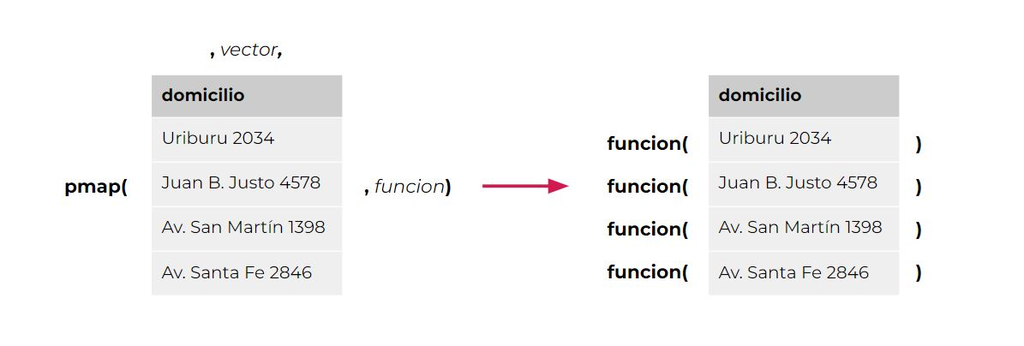

Para obtener los resultados deseados, vamos a tener que crear lo que en R le llamamos **función** y luce así:

*nombre* **<- function(***argumentos***) {** *operaciones* **}**

De lado izquierdo de la “flechita” irá el nombre que le asignamos a nuestra función y que luego nos servirá para ejecutarla, al igual que como hacemos con cualquier otra función de R que ya conozcamos.

Luego utilizamos la función llamada `function()` donde entre los paréntesis asignaremos los argumentos o variables que la función va a utilizar al momento de realizar las operaciones. Se escriben entre “()” y se separan por “,” si son 2 o más.

Por último, asignamos dentro de los **{}** todas las operaciones que queremos que se realicen cuando la función sea ejecutada.

Para que se entienda mejor como funciona, carguemos un dataset que tenga más de un registro con dirección así hacemos luego nuestra primera función. En este caso, trabajemos con las Sedes Comunales que existen en la Ciudad Autónoma de Buenos Aires y que se encuentran en [este link](https://data.world/angie-scetta/sedes-comunales-caba) pero que fueron descargadas previamente del portal de datos abiertos [BAData](https://data.buenosaires.gob.ar/dataset/sedes-comunales):

```r
sedes_comunales <- read.csv("data/sedes_comunales_caba.csv", encoding = "UTF-8")
```

Como se imaginarán, en este caso el campo/columna que nos ayudará a georreferenciar los registros será el que se llama “domicilio”, por lo tanto, debe estar escrito lo más claro posible y con el mayor nivel de detalle. Para lograr esto, utilizaremos `paste()` para agregar luego de la dirección una aclaración de la *Ciudad, Provincia y País* donde queremos ubicar la información:

```r
sedes_comunales <- sedes_comunales %>%
  mutate(domicilio = paste(domicilio, ", CABA, Buenos Aires, Argentina"))
```

Veamos el resultado:

```r
head(sedes_comunales)
```

```
##              nombre
## 1    Sede Comunal 1
## 2    Sede Comunal 2
## 3 Subsede Comunal 3
## 4    Sede Comunal 4
## 5    Sede Comunal 3
## 6    Sede Comunal 6
##                                                      domicilio
## 1               Humberto 1 250 , CABA, Buenos Aires, Argentina
## 2                 Uriburu 1022 , CABA, Buenos Aires, Argentina
## 3                  Moreno 2301 , CABA, Buenos Aires, Argentina
## 4     Del Barco Centenera 2906 , CABA, Buenos Aires, Argentina
## 5                 Sarandi 1273 , CABA, Buenos Aires, Argentina
## 6 Av. Patricias Argentinas 277 , CABA, Buenos Aires, Argentina
```

Ya estamos listos para hacer nuestra primera función, a la que llamaremos **geocode_funcion**:

```r
geocode_funcion <- function(x){
  df <- geocode_OSM(x, as.data.frame = TRUE, keep.unfound=TRUE)
}
```

¿Qué hicimos? ¿Qué usamos como argumento y qué usamos como operación?

1. El **argumento** elegido fue uno solo llamado “x” ya que esta función trabajará sobre una única columna del dataset. Nótese que el argumento debe aparecer tanto entre los () de `function()` como dentro de `geocode_OSM()`.
2. La **operación** asignada fue una geolocalización con `geocode_OSM()` sobre todos los valores del argumento “x” y se ajustaron 2 parámetros: *as.data.frame=TRUE* para que el resultado sea un dataframe y no una lista; y *keep.unfound=TRUE* para que, si la función no encuentra alguna dirección en OSM, no arroje error y pueda seguir con el siguiente registro.

Tal como se mencionó más arriba, un punto importante a destacar es que la función `pmap()` necesita si o si que le asignemos un vector para que lo tome como *input* y repita sobre cada elemento la función elegida, que en este caso será **geocode_funcion**. Por lo tanto es necesario que transformemos los domicilios del dataset sedes_comunales a un vector con la función `list()`:

```r
domicilio <- list(sedes_comunales$domicilio)
```

Ahora si, ya estamos en condiciones de utilizar `pmap()` para geolocalizar todas las Sedes Comunales de CABA:

```r
domicilio <- pmap(domicilio, geocode_funcion)
```

Veamos que resultado obtuvimos:

```r
summary(domicilio)
```

```
##       Length Class      Mode
##  [1,] 7      data.frame list
##  [2,] 7      data.frame list
##  [3,] 7      data.frame list
##  [4,] 7      data.frame list
##  [5,] 7      data.frame list
##  [6,] 7      data.frame list
##  [7,] 7      data.frame list
##  [8,] 7      data.frame list
##  [9,] 7      data.frame list
## [10,] 7      data.frame list
## [11,] 7      data.frame list
## [12,] 7      data.frame list
## [13,] 7      data.frame list
## [14,] 7      data.frame list
## [15,] 7      data.frame list
## [16,] 7      data.frame list
## [17,] 7      data.frame list
## [18,] 7      data.frame list
## [19,] 7      data.frame list
## [20,] 7      data.frame list
```

Podemos observar que la función nos devolvió una lista con todos los dataframes de los resultados de las 20 direcciones geolocalizadas. Para poder analizar y mapear los resultados, necesitamos utilizar `reduce()` con el fin de reducir la lista e ir uniendo todas las filas para que nos devuelva el resultado como un dataset único:

```r
domicilio <- domicilio %>%
  reduce(rbind)
```

```r
summary(domicilio)
```

```
##     query                lat              lon            lat_min
##  Length:20          Min.   :-34.68   Min.   :-58.51   Min.   :-34.69
##  Class :character   1st Qu.:-34.63   1st Qu.:-58.47   1st Qu.:-34.63
##  Mode  :character   Median :-34.62   Median :-58.44   Median :-34.62
##                     Mean   :-34.61   Mean   :-58.44   Mean   :-34.61
##                     3rd Qu.:-34.59   3rd Qu.:-58.40   3rd Qu.:-34.59
##                     Max.   :-34.55   Max.   :-58.37   Max.   :-34.55
##     lat_max          lon_min          lon_max
##  Min.   :-34.68   Min.   :-58.51   Min.   :-58.51
##  1st Qu.:-34.63   1st Qu.:-58.47   1st Qu.:-58.47
##  Median :-34.62   Median :-58.44   Median :-58.44
##  Mean   :-34.61   Mean   :-58.44   Mean   :-58.44
##  3rd Qu.:-34.59   3rd Qu.:-58.40   3rd Qu.:-58.40
##  Max.   :-34.55   Max.   :-58.37   Max.   :-58.37
```

Listo, ya podemos mapear:

```r
leaflet(domicilio) %>%
  addProviderTiles(providers$CartoDB.DarkMatter) %>%
  addCircleMarkers(~lon, ~lat,
                   color = "white")
```

[interactive chart not shown]

Por último, completemos nuestro dataset sedes_comunales con la información obtenida:

```r
sedes_comunales <- sedes_comunales %>%
  left_join(domicilio, by=c("domicilio"="query"))
```

Y volvamos a mapear pero agregando un “pop-up” que nos indique el nombre de cada Sede Comunal:

```r
leaflet(sedes_comunales) %>%
  addProviderTiles(providers$CartoDB.DarkMatter) %>%
  addCircleMarkers(~lon, ~lat,
                   color = "white",
                   popup = ~nombre)
```

[interactive chart not shown]

## RUTEOS: DISTANCIA Y DURACIÓN

La duración de los recorridos que se realizan a diario en la Ciudad y las distancias entre los diferentes puntos de interés son un tema muy relevante a la hora de analizar las dinámicas urbanas. Por suerte desde R podemos conectarnos al [servicio de ruteo de OSRM](http://project-osrm.org/), un paquete de uso libre, basado en datos de OpenStreetMap, que es muy útil a la hora de calcular distancias (km) y tiempos de viaje (minutos) entre 2 o más puntos georreferenciados. Pueden consultar la documentación de la librería [aquí](https://cran.r-project.org/web/packages/osrm/osrm.pdf).

El paquete se compone de 4 funciones que son:

- osrmRoute(): camino más corto entre 2 puntos
- osrmTable(): matriz de tiempos de viaje entre puntos
- osrmTrip(): viaje entre múltiples puntos
- osrmIsochrone(): polígono de isocronas

En la clase de hoy trabajaremos con la función `osrmRoute()` para descubrir **que Sede Comunal (ya geolocalizadas) es la más cercana a la Sede de FLACSO de Buenos Aires para ir en bicicleta**.

La función `osrmRoute()` necesita que le asignemos toda la información relacionada al origen y al destino, es decir que debemos tener como mínimo 6 columnas que indiquen:

- ID sitio origen (en nuestro caso FLACSO_arg$nombre)
- Longitud sitio origen (en nuestro caso FLACSO_arg$lon)
- Latitud sitio origen (en nuestro caso FLACSO_arg$lat)
- ID sitio destino (en nuestro caso sedes_comunales$nombre)
- Longitud sitio destino (en nuestro caso sedes_comunales$lon)
- Latitud sitio destino (en nuestro caso sedes_comunales$lat)

### RUTEO SIMPLE

Comencemos con un primer ejemplo de un ruteo simple, es decir de un punto a otro punto. Para esto, quedémonos solo con la primer Sede Comunal del dataset:

```r
sede1 <- sedes_comunales[1,]
```

```r
sede1
```

```
##           nombre                                      domicilio       lat
## 1 Sede Comunal 1 Humberto 1 250 , CABA, Buenos Aires, Argentina -34.62062
##         lon   lat_min   lat_max   lon_min   lon_max
## 1 -58.36844 -34.62062 -34.62061 -58.36844 -58.36837
```

La primera es la Sede Comunal 1, así que trabajemos con esa y hagamos un ruteo con `osrmRoute()` para poder calcular la distancia y el tiempo de viaje entre la Sede de FLACSO y la Sede Comunal 1:

```r
ruteo1 <- osrmRoute(src = c(FLACSO_arg$nombre, FLACSO_arg$lon, FLACSO_arg$lat),
                    dst = c(sede1$nombre, sede1$lon, sede1$lat),
                          returnclass = "sf",
                          overview = "full",
                          osrm.profile = "bike")
```

Como verán tuvimos que asignar 5 parámetros a la función:

1. En **src** tenemos que indicar el origen del ruteo con un identificador del sitio (nombre en este caso) y sus coordenadas.
2. En **dst** tenemos que indicar el destino del ruteo con un identificador del sitio (nombre en este caso) y sus coordenadas.
3. En **returnclass** tenemos que indicar el tipo de objeto que queremos que nos devuelva la función, en este caso, un objeto espacial sf (línea de recorrido).
4. En **overview** debemos indicar la calidad con la que se genera la geometría: *full* para obtener la mayor precisión, *simplified* para menor precisión y *FALSE* para obtener solo tiempo y distancia (sin geometría).
5. En **osrm.profile** indicaremos el modo de transporte en el que queremos realizar el ruteo: *car, bike o foot*.

Veamos el resultado que obtuvimos:

```r
ruteo1
```

```
## Simple feature collection with 1 feature and 4 fields
## Geometry type: LINESTRING
## Dimension:     XY
## Bounding box:  xmin: -58.39499 ymin: -34.62062 xmax: -58.36844 ymax: -34.60167
## Geodetic CRS:  WGS 84
##                          src            dst duration distance
## FLACSO_Sede Comunal 1 FLACSO Sede Comunal 1   19.945   4.1299
##                                             geometry
## FLACSO_Sede Comunal 1 LINESTRING (-58.39499 -34.6...
```

Reflejemos este recorrido en el mapa:

```r
leaflet(ruteo1) %>%
    addProviderTiles(providers$CartoDB.DarkMatter) %>%
    addPolylines(color = "red",
                 label = paste("Distancia:", ruteo1$distance, "|",
                               "Duración:", ruteo1$duration))
```

[interactive chart not shown]

Probemos agregar los puntos de origen y destino sumando los objetos FLACSO_arg (que tiene las coordenadas de origen) y sede1 (que tiene las coordenadas de destino) con `addCircleMarkers()`:

```r
leaflet(ruteo1) %>%
    addProviderTiles(providers$CartoDB.DarkMatter) %>%
    addPolylines(color = "red",
                 label = paste("Distancia:", ruteo1$distance, "|",
                               "Duración:", ruteo1$duration)) %>%
  addCircleMarkers(data=FLACSO_arg, ~lon, ~lat,
                   popup = ~nombre,
                   color="white") %>%
  addCircleMarkers(data=sede1, ~lon, ~lat,
                   popup = ~nombre,
                   color="white")
```

[interactive chart not shown]

### RUTEO MÚLTIPLE

Dado que la pregunta inicial que nos hicimos fue qué Sede Comunal está más cerca de FLACSO, el próximo paso es hacer un ruteo múltiple desde FLACSO hasta las 20 Sedes Comunales. Como ya se estarán imaginando, debemos usar nuevamente `pmap()` y crear nuestra función de ruteo múltiple.

```r
ruteo_funcion <- function(nombre_origen, lon_origen, lat_origen,
                          nombre_destino, lon_destino, lat_destino) {
  ruta <- osrmRoute(src = c(nombre_origen, lon_origen, lat_origen),
                    dst = c(nombre_destino, lon_destino, lat_destino),
                    returnclass = "sf",
                    overview = "full",
                    osrm.profile = "bike")
}
```

Y antes de usar `pmap()` debemos preparar nuestro vector con toda la información necesaria para el ruteo en cuestión:

```r
ruteo2 <- list(FLACSO_arg$nombre, FLACSO_arg$lon, FLACSO_arg$lat,
               sedes_comunales$nombre, sedes_comunales$lon, sedes_comunales$lat)
```

```r
ruteo2 <- pmap(ruteo2, ruteo_funcion) %>%
  reduce(rbind)
```

Veamos los resultados:

```r
summary(ruteo2)
```

```
##      src                dst               duration         distance
##  Length:20          Length:20          Min.   : 4.047   Min.   : 0.8903
##  Class :character   Class :character   1st Qu.:12.880   1st Qu.: 2.5752
##  Mode  :character   Mode  :character   Median :25.220   Median : 5.8719
##                                        Mean   :27.969   Mean   : 6.3835
##                                        3rd Qu.:41.415   3rd Qu.: 9.4562
##                                        Max.   :58.090   Max.   :13.4965
##           geometry
##  LINESTRING   :20
##  epsg:4326    : 0
##  +proj=long...: 0
##
##
##
```

Y veamos cuál es la Sede más cercana:

```r
ruteo2 %>%
  filter(distance==min(distance))
```

```
## Simple feature collection with 1 feature and 4 fields
## Geometry type: LINESTRING
## Dimension:     XY
## Bounding box:  xmin: -58.39888 ymin: -34.60216 xmax: -58.39499 ymax: -34.59671
## Geodetic CRS:  WGS 84
##                          src            dst duration distance
## FLACSO_Sede Comunal 2 FLACSO Sede Comunal 2 4.046667   0.8903
##                                             geometry
## FLACSO_Sede Comunal 2 LINESTRING (-58.39499 -34.6...
```

Ahora hagamos un mapa con todos los recorridos:

```r
leaflet(ruteo2) %>%
    addProviderTiles(providers$CartoDB.DarkMatter) %>%
    addPolylines(color = "red",
                 label = paste("Distancia:", ruteo1$distance, "|",
                               "Duración:", ruteo1$duration))%>%
  addCircleMarkers(data=FLACSO_arg, ~lon, ~lat,
                   popup = ~nombre,
                   color="white") %>%
  addCircleMarkers(data=sedes_comunales, ~lon, ~lat,
                   popup = ~nombre,
                   color="gray")
```

[interactive chart not shown]

Y ajustemos un poco la estética como por ejemplo:

- Paleta de colores de los recorridos con su respectiva referencia.
- Parámetros de los marcadores/círculos: tamaño, transparencia, etc.
- Parámetros en las etiquetas: agregar mayor detalle en el texto y redondear decimales para distancia y duración.
- Parámetros en los pop-up: agregar mayor detalle en el texto.

```r
paleta <- c(low="gold", high= "deeppink4")
```

```r
leaflet(ruteo2) %>%
    addProviderTiles(providers$CartoDB.DarkMatter) %>%
    addPolylines(color = ~colorNumeric(paleta, ruteo2$distance)(distance),
                 label = paste("Desde", ruteo2$src, "hasta", ruteo2$dst, "|", "Distancia:", round(ruteo2$distance, 2), "km", "|", "Duración:", round(ruteo2$duration, 2), "min")) %>%
  addLegend("bottomright", pal = colorNumeric(paleta, ruteo2$distance), values = ~distance,
            title = "Distancia",
            labFormat = labelFormat(suffix = "km")) %>%
  addCircleMarkers(data=FLACSO_arg, ~lon, ~lat,
                   popup = paste("ORIGEN:", FLACSO_arg$nombre),
                   color="white",
                   fillOpacity = 1,
                   radius=8) %>%
  addCircleMarkers(data=sedes_comunales, ~lon, ~lat,
                   popup = paste("DESTINO:", sedes_comunales$nombre),
                   color="gray",
                   fillOpacity = 1,
                   radius=6)
```

[interactive chart not shown]

Por último, probemos cambiando el mapa de fondo por uno más claro:

```r
leaflet(ruteo2) %>%
    addProviderTiles(providers$CartoDB.Positron) %>%
    addPolylines(color = ~colorNumeric(paleta, ruteo2$distance)(distance),
                 label = paste("Desde", ruteo2$src, "hasta", ruteo2$dst, "|", "Distancia:", round(ruteo2$distance, 2), "km", "|", "Duración:", round(ruteo2$duration, 2), "min")) %>%
  addLegend("bottomright", pal = colorNumeric(paleta, ruteo2$distance), values = ~distance,
            title = "Distancia",
            labFormat = labelFormat(suffix = "km")) %>%
  addCircleMarkers(data=FLACSO_arg, ~lon, ~lat,
                   popup = paste("ORIGEN:", FLACSO_arg$nombre),
                   color="black",
                   fillOpacity = 1,
                   radius=8) %>%
  addCircleMarkers(data=sedes_comunales, ~lon, ~lat,
                   popup = paste("DESTINO:", sedes_comunales$nombre),
                   color="gray",
                   fillOpacity = 1,
                   radius=6)
```

[interactive chart not shown]

## EJERCICIOS DE PRÁCTICA

1. Elegir un dataset que contenga servicios esenciales (hospitales, escuelas, comisarías, etc) de alguna Ciudad que sea de su interés. Es necesario que tenga una columna con los domicilios.
2. Realizar todas las funciones que sean necesarias para poder georreferenciar todos los servicios del punto 1 y mapearlos.
3. Elegir un punto céntrico de la Ciudad donde estén trabajando, por ejemplo la Casa de Gobierno y estimar la distancia entre este y todos los ítems que componen la capa del punto 1. Describir los resultados obtenidos y hacer un mapa interactivo con los ruteos.